# Homework#1_Om_Gaikwad

```python
import numpy as np
import matplotlib.pyplot as plt
```

## Question 1

Print the result of **A+B** and explain the mechanism behind this.

You answer:

```python
A = np.array([[0, 1, 2]])
B = np.array([[10, 10, 10], [20, 20, 20], [30, 30, 30]])
# Broadcast is essentially when Numpy performs operations on arrays that have different shapes
#In this case, A has a shape (1, 3) and B has shape (3, 3). Here, numpy modifies A to shape (3, 3) to make the operation possible
result = A + B

print ("A + B = ", result)
```

```
A + B =  [[10 11 12]
 [20 21 22]
 [30 31 32]]
```

## Question 2

The broadcasting rule can be also applied to the multiplication. In this question, two numpy arrays of different shapes are given, check their shape first. And then, reshape one of the array so that you can produce exactly the same result given below.

```python
A = np.array([1, 2, 3, 4])
B = np.array([[1, 2, 3, 4]])

# Checking shapes
print ("Shape of A: ", A.shape)
print ("Shape of B: ", B.shape)

# to allow braodcsting, we will change the shape of A to (4, 1)
mod_A = A.reshape(4, 1)
# insert code
result = mod_A * B

print ("Multiplication result: \n", result)
```

```
Shape of A:  (4,)
Shape of B:  (1, 4)
Multiplication result:
 [[ 1  2  3  4]
 [ 2  4  6  8]
 [ 3  6  9 12]
 [ 4  8 12 16]]
```

**Note in the following questions, the figures need to be as similar as possible to the outputs we gave you.**

## Question 3

Generate an array with 100 rows and 2 cols at random. Plot it by Matplotlib. You should consider the plotting setting in terms of titles, legends, names of the x and y axe, etc.

**Firstly, please set your student id as the seed number. Like np.random.seed(20016329).**

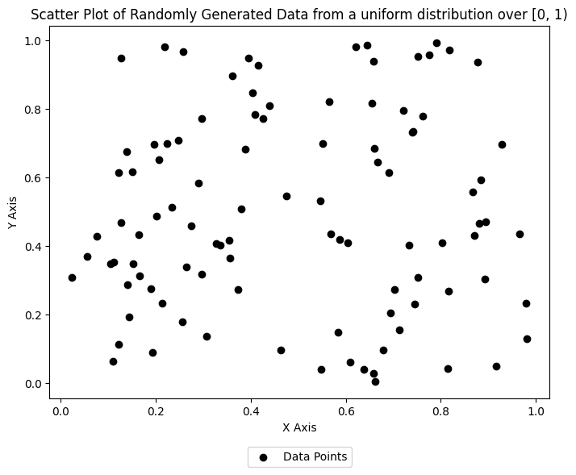

```python
np.random.seed(20002350) # Please use your student id as the seed number

# Generating the random data - 100 rows and 2 cols
array = np.random.rand(100, 2)

# Create the plot
fig, axs = plt.subplots(figsize=(8, 6))
axs.scatter(array[:, 0], array[:, 1], color='black', marker='o', label="Data Points")

axs.set_title('Scatter Plot of Randomly Generated Data from a uniform distribution over [0, 1)')
axs.set_xlabel('X Axis')
axs.set_ylabel('Y Axis')
axs.legend(loc='lower center', bbox_to_anchor=(0.5, -0.2))  # Legend at the bottom


# Show the plot
plt.show()
```

## Question 4

For the previous generated data, consider each row of the array as an individual data point, with the two columns representing its distinct features. Identify the data points with the smallest and largest sum of features. Mark them in red and blue in the figure respectively.

Hint: You can compute the sum of each row and store it in an array named "sums". Then find the minimum or maximum index of this array.

```
Smallest sum index: 55, Largest sum index: 4
```

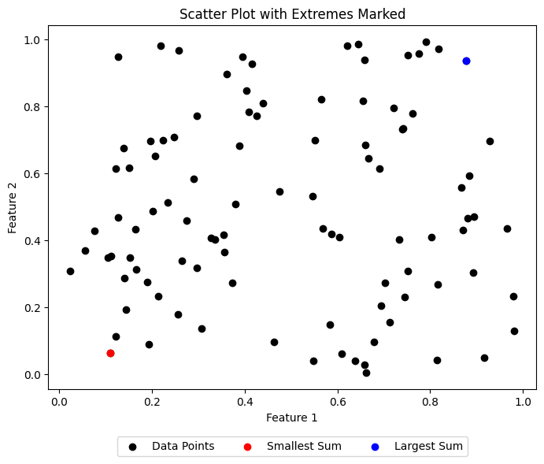

```python
# Compute the sum of each row
sums = np.sum(array, axis=1)

# Identify the indices of the min and max sum
min_index = np.argmin(sums)
max_index = np.argmax(sums)

print(f"Smallest sum index: {min_index}, Largest sum index: {max_index}")

# Create the plot
fig, axs = plt.subplots(figsize=(8, 6))
axs.scatter(array[:, 0], array[:, 1], color='black', marker='o', label="Data Points")

# Smallest sum point in red
axs.scatter(array[min_index, 0], array[min_index, 1], color='red', marker='o', label="Smallest Sum")

# Largest sum point in blue
axs.scatter(array[max_index, 0], array[max_index, 1], color='blue', marker='o', label="Largest Sum")

# Set plot
axs.set_title('Scatter Plot with Extremes Marked')
axs.set_xlabel('Feature 1')
axs.set_ylabel('Feature 2')
axs.legend(loc='lower center', bbox_to_anchor=(0.5, -0.2), ncol=3)  # Legend at the bottom


plt.show()
```

## Question 5

Add two lines representing the mean of the Feature 1 and the 25% quantile of the Feature 2 seperately. Add the legend of the two lines.

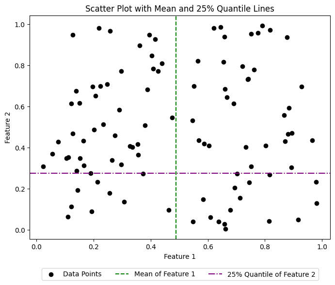

```python
# Compute the mean of Feature 1 and the 25% quantile of Feature 2
mean_feature1 = np.mean(array[:, 0])
quantile_25_feature2 = np.quantile(array[:, 1], 0.25)

# Create the plot
fig, axs = plt.subplots(figsize=(8, 6))
axs.scatter(array[:, 0], array[:, 1], color='black', marker='o', label="Data Points")

#Vertical line for the mean of Feature 1
axs.axvline(x=mean_feature1, color='green', linestyle='--', label="Mean of Feature 1")

#Horizontal line for the 25% quantile of Feature 2
axs.axhline(y=quantile_25_feature2, color='purple', linestyle='-.', label="25% Quantile of Feature 2")

# Set plot title
axs.set_title('Scatter Plot with Mean and 25% Quantile Lines')
axs.set_xlabel('Feature 1')
axs.set_ylabel('Feature 2')
axs.legend(loc='lower center', bbox_to_anchor=(0.5, -0.2), ncol=3)  # Legend at the bottom


plt.show()
```

## Question 6

Display the figures in Quesiton 3-6 in one figure. Please follow the given output to adjust the arangement . So that you can observe and compare the figures more convenienty. Don't forget parts of the original figures change.

Note that the first subplot is given. You just need to plot the other three figures.

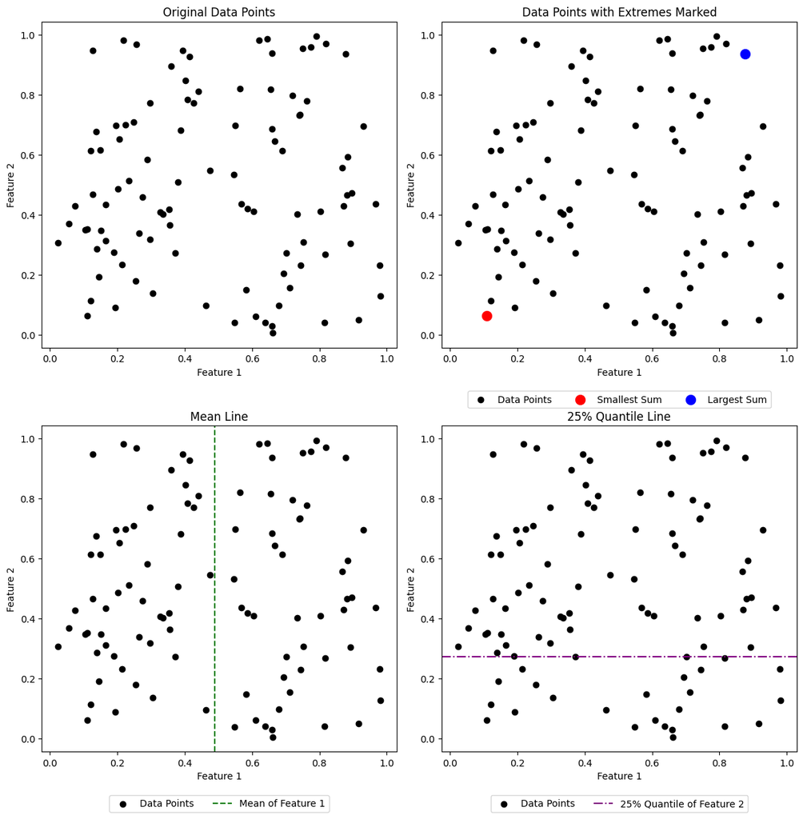

```python
fig, axs = plt.subplots(2, 2, figsize=(12, 12))

axs[0, 0].scatter(array[:, 0], array[:, 1], color='black', marker='o')
axs[0, 0].set_title('Original Data Points')
axs[0, 0].set_xlabel('Feature 1')
axs[0, 0].set_ylabel('Feature 2')

# Second subplot: Highlight Min/Max Sum Points
axs[0, 1].scatter(array[:, 0], array[:, 1], color='black', marker='o', label="Data Points")
axs[0, 1].scatter(array[min_index, 0], array[min_index, 1], color='red', marker='o', s=100, label="Smallest Sum")
axs[0, 1].scatter(array[max_index, 0], array[max_index, 1], color='blue', marker='o', s=100, label="Largest Sum")
axs[0, 1].set_title('Data Points with Extremes Marked')
axs[0, 1].set_xlabel('Feature 1')
axs[0, 1].set_ylabel('Feature 2')
axs[0, 1].legend(loc='lower center', bbox_to_anchor=(0.5, -0.2), ncol=3)  # Legend at the bottom

# Third subplot: Mean and 25% Quantile Lines
axs[1, 0].scatter(array[:, 0], array[:, 1], color='black', marker='o', label="Data Points")
axs[1, 0].axvline(x=mean_feature1, color='green', linestyle='--', label="Mean of Feature 1")
axs[1, 0].set_title('Mean Line')
axs[1, 0].set_xlabel('Feature 1')
axs[1, 0].set_ylabel('Feature 2')
axs[1, 0].legend(loc='lower center', bbox_to_anchor=(0.5, -0.2), ncol=2)  # Legend at the bottom

# Fourth subplot: Combined View
axs[1, 1].scatter(array[:, 0], array[:, 1], color='black', marker='o', label="Data Points")
axs[1, 1].axhline(y=quantile_25_feature2, color='purple', linestyle='-.', label="25% Quantile of Feature 2")
axs[1, 1].set_title('25% Quantile Line')
axs[1, 1].set_xlabel('Feature 1')
axs[1, 1].set_ylabel('Feature 2')
axs[1, 1].legend(loc='lower center', bbox_to_anchor=(0.5, -0.2), ncol=2)  # Legend at the bottom



# Adjust layout and display the plot
plt.tight_layout()
plt.show()
```